# CIND 123 - Data Analytics: Basic Methods

# Assignment 1 (10%)

### CIND 123-DHA Student ID: 501068792

## Instructions

Use RStudio for this assignment. Complete the assignment by inserting your R code wherever you see the string “#INSERT YOUR ANSWER HERE”.

Submit **both** the rmd and generated output files. Failing to submit both files will be subject to mark deduction.

## Sample Question and Solution

Use `seq()` to create the vector $(1,2,3,\ldots,10)$.

```r
seq(1,10)
```

```
##  [1]  1  2  3  4  5  6  7  8  9 10
```

## Question 1

1. Use the `seq()` function to create the vector $(1, 7, 13, \ldots, 61)$. Note that each term in this sequence is of the form $1 + 6n$ where $n = 0, \ldots, 10$.

```r
seq(1, 61, by=6)
```

```
##  [1]  1  7 13 19 25 31 37 43 49 55 61
```

2. Use `rep()` to create the vector $(2,3,4,\dots,2,3,4, \dots,2,3,4)$ in which the sequence $(2,3,4)$ is repeated 5 times.

```r
rep(2:4, 5)
```

```
##  [1] 2 3 4 2 3 4 2 3 4 2 3 4 2 3 4
```

3. To convert factor to number, would it be correct to use the following commands? Explain your answer.

`factorVar <- factor(c(1, 6, 5.4, 3.2));as.numeric(factorVar)`

```r
#No. When using "as.numeric" command to convert a factor, R will automatically assign numbers to the categories of the factor. Therefore, it is necessary to first convert a factor to character and then to numeric. The right command should be:

factorVar <- factor(c(1, 6, 5.4, 3.2))
as.numeric(as.character(factorVar))
```

```
## [1] 1.0 6.0 5.4 3.2
```

4. A comma-separated values file `dataset.csv` consists of missing values represented by question marks (`?`) and exclamation mark (`!`). How can you read this type of files in R?

```r
#We can replace the missing values represented by "?" or "!" with a value that can be treated or excluded later. For example, we can use the command is.na(dataset) to detect any missing data in the dataset and then assign them to a value such as 0.
```

## Question 2

1. Compute:
   $$\sum_{n=10}^{100} n^3$$

```r
sum((10:100)^3)
```

```
## [1] 25500475
```

2. Compute:
   $$\sum_{n=1}^{10}\left(\frac{2^{n}}{n^2} + \frac{n^{4}}{4^{n}}\right)$$

```r
n <- 1:10
sum(((2^n)/(n^2))+((n^4)/(4^n)))
```

```
## [1] 35.80589
```

3. Compute:
   $$\sum_{n=0}^{10} \frac{1}{(n+1)!}$$

```r
m <- 0:10
sum(1/factorial(m+1))
```

```
## [1] 1.718282
```

4. Compute:
   $$\prod_{n=3}^{33} \left(3n + \frac{3}{\sqrt[3]{n}}\right)$$

```r
a <- 3:33
prod((3*a)+(3/(a^(1/3))))
```

```
## [1] 9.054339e+51
```

5. Explain the output of this R-command: `c(0:5)[NA]`

```r
c(0:5)[NA]
```

```
## [1] NA NA NA NA NA NA
```

```r
#c(0;5)[x] means to extract the xth number in the vector; NA means unknown or missingness, and is not a valid index in R, as an index must be an integer. As such, the above command returns as:
```

6. What is the difference between is.vector() and is.numeric() functions?

```r
#"is.vector" is used to verify is the object between the brackets is stored as a vector by R. The result is either "True" (indicating the object is a vector) or "False" (indicating the contrary).

#"is.numeric" is used to verify is the object between the brackets is stored as a number by R. The result is either "True" or "False".
```

7. List at least three advantages and three disadvantages of using `RShiny` package?

```r
#Advantage 1: RShiny has an extensive gallary for data visualization; therefore, it is an excellent tool to visualize complex datasets.

#Advantage 2: RShiny is excellent for building interactive data visualizations by itself. As such, no HTML, Javascript or CSS knowledge is required for the purposes of customizing datasets and user interface.

#Advantage 3: RShiny can be automated to perform a set of operations

#Disadvantage 1: In order to use RShiny, one will need to learn the R language, while other software programs such as Tableau have a much flat learning curve with coding mostly reserved for advanced users.

#Disadvantage 2: Becasue RShiny is open sourced, there is no way to block someone from accessing the app once it is hosted online.

#Disadvantage 3: The free version only allows for 25 active hours of app running time per month. You will need to pay to get unlimited access.
```

## Question 3

`iris` dataset gives the measurements in centimeters of the variables sepal length, sepal width, petal length and petal width, respectively, for 50 flowers from each of 3 species of iris. The species are Iris setosa, versicolor, and virginica.

Install the `iris` dataset on your computer using the command `install.packages("datasets")`. Then, load the `datasets` package into your session using the following command.

```r
library(datasets)
```

1. Display the first six rows of the `iris` data set.

```r
head(iris)
```

```
##   Sepal.Length Sepal.Width Petal.Length Petal.Width Species
## 1          5.1         3.5          1.4         0.2  setosa
## 2          4.9         3.0          1.4         0.2  setosa
## 3          4.7         3.2          1.3         0.2  setosa
## 4          4.6         3.1          1.5         0.2  setosa
## 5          5.0         3.6          1.4         0.2  setosa
## 6          5.4         3.9          1.7         0.4  setosa
```

2. Compute the average of the first four variables (Sepal.Length, Sepal.Width, Petal.Length and Petal.Width) using `sapply()` function.

Hint: You might need to consider removing the `NA` values, otherwise the average will not be computed.

```r
sapply(iris[1:4] ,mean ,rm = NA )
```

```
## Sepal.Length  Sepal.Width Petal.Length  Petal.Width
##     5.843333     3.057333     3.758000     1.199333
```

3. Show how to use R to replace the missing values in this dataset with plausible ones.

```r
iris[is.na(iris)] <- 0
```

4. Compute the standard deviation for only the first and the third variables (Sepal.Length and Petal.Length)

```r
sd(iris [,1] )
```

```
## [1] 0.8280661
```

```r
sd(iris [,3] )
```

```
## [1] 1.765298
```

5. Construct a boxplot for `Sepal.Width` variable, then display the values of all the outliers. Explain how these outliers have been calculated.

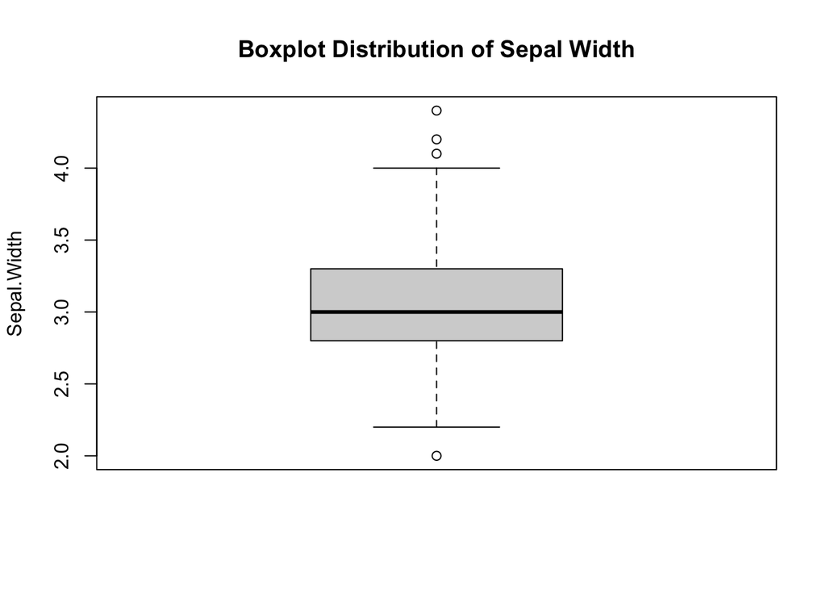

```r
boxplot(iris$Sepal.Width, ylab="Sepal.Width", main = "Boxplot Distribution of Sepal Width")
```

```r
#Outliners are data points that fall below the lower fence or above the upper fence. The lower fence is calculated as Q1-1.5*IQR, and the upper fence is calculated as Q3+1.5*IQR.
```

6. Compute the upper quartile of the `Sepal.Width` variable with two different methods.

```r
#Method 1
summary(iris$Sepal.Width)
```

```
##    Min. 1st Qu.  Median    Mean 3rd Qu.    Max.
##   2.000   2.800   3.000   3.057   3.300   4.400
```

```r
#Method 2
quantile(iris$Sepal.Width, 0.75)
```

```
## 75%
## 3.3
```

7. Construct a pie chart to describe the species with ‘Sepal.Length’ less than 7 centimeters.

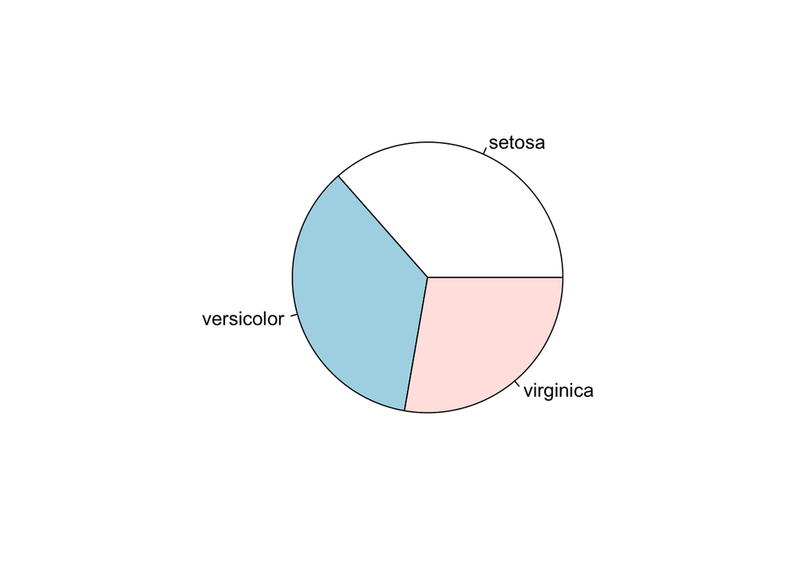

```r
lessthan7 <- subset(iris, iris$Sepal.Length < 7)
species <- table(lessthan7$Species)
pie(species)
```

END of Assignment #1.